# Targets

Curbcut

# Housing targets modelling strategy

To answer the question “how many housing units should the City of Laval be building each year”, it is necessary to first answer two other questions. The first is “how many households are expected (or desired) to be living in the City each year”. The second is “how many dwelling units will it be necessary to build to ensure that there is sufficient housing for that number of households”.

We answer the first question by using the three scenarios for household growth to 2051 in the City of Laval which have been produced by the ISQ: a reference scenario, a weak scenario, and a strong scenario. We answer the second question by using historical trends to model a set of factors related to dwelling occupancy, housing construction and demolition, and household housing preferences.

Below we present the detailed steps involved in this modeling exercise, along with the resulting housing targets. But first we identify a set of important qualifications about what can and cannot be inferred from this analysis.

First, it is important to be clear about what the ISQ household growth scenarios mean, and how they are incorporated into our housing targets. These scenarios represent the ISQ’s best guess about how a range of factors at the local, regional, provincial, national and global scales will translate into household formation in Laval, and, given the inherent uncertainty in those factors, represent a rough guide to several currently plausible outcomes. However, a fundamental limitation of using the ISQ’s household projections to guide City housing policy is that City housing policy is implicitly one of the most important inputs to these projections. Under all of its scenarios, the ISQ is assuming that there will be more households in Laval in 2051 than there are today, and under two of the three scenarios the number of households is expected to continue increasing each year. However, household growth can only occur if the City permits sufficient new housing construction. For example, if the City decides to permit no new housing construction between now and 2051, then the number of households in Laval will stagnate and likely decline (thanks to building attrition), regardless of what the ISQ projects. More realistically, if the City only permits sufficient housing construction to reach half the number of new households that the ISQ projects will be present in Laval in 2051, then the number of households will necessarily fall short of the ISQ projection.

The housing targets produced in this analysis should therefore be understood as the targets which will allow the ISQ projections to be realized, subject to the ISQ’s other assumptions remaining plausible (e.g. the Québec population ages as it is expected to, and immigration proceeds as it is expected to) and subject to the housing dynamics captured in the remainder of our model. If the City has different normative goals for household growth in Laval, those can be substituted into the model in place of the ISQ’s projections, and the model will produce the resulting targets for the amount of housing construction necessary to realize those household growth goals.

Second, it is important to clarify which housing outcomes the City has some control over, and how. The key dynamics of housing systems are regional in nature; in particular, the region is the scale at which aggregate housing demand is produced, and the scale at which demand and supply jointly determine housing costs. This is because households are much more indifferent to their location within a region than they are to their location between regions: in the case of the Montreal region, while each individual household is likely to have some preferences as to whether they live in Laval or Longueuil or elsewhere, in general households’ locational choices are most strictly limited by daily commuting needs which anchor them to a given region. It is plausible to commute from Laval to Longueuil or vice-versa, but it is not plausible to commute from Laval to Quebec City, or from Laval to Ottawa.

Aggregate housing demand is the amount of housing desired at different price points by all the households currently living in the region or interested in living in the region (plus the housing desired by non-local investors). If the amount of this demand increases (for example because the Montreal economy is booming, because the Montreal region becomes a more attractive destination for international migration, or because national interest rates drop), then, given a fixed amount of regional housing supply, regional housing costs will increase. Likewise, as any location in the region adds housing supply, then, given a fixed amount of regional housing demand, regional housing costs will decrease. While a new influx of housing in a particular location will likely result in a short-term drop in housing costs relative to other locations in the region which did not receive that influx, in the long run the downward price pressure of new supply will tend to equilibriate across the entire region, as individual households’ locational preferences update in response to changing prices.

The result of this regional housing price equilibrium process is that, broadly speaking, local housing costs are jointly driven by, on the one hand, the relationship between regional demand and supply (which answers the question: how costly is housing in general?), and, on the other, the relative desirability of its housing vis-a-vis the housing elsewhere in the region (which answers the question: given baseline regional housing costs, how much more or less expensive is local housing because of its relative desirability?).

The key implication of this analysis for the City of Laval is that the City’s major lever for affecting affordability within the private housing market is the type of construction rather than the volume of construction it allows. If Laval were to receive a boom in new housing construction, some of the resulting supply would tend to reduce housing costs in Laval, particularly in the short-term, but much of the effect would be reduced housing costs elsewhere in the Montreal region. (To be clear, there are other, non-affordability reasons why the City might want more housing built locally. For example, more housing in Laval will generate more local demand for Laval businesses.)

By contrast, if the City gradually changes the mixture of housing types in Laval through its control of land-use zoning and permitting, then it will gradually change which portion of aggregate regional housing demand is satisfied in Laval. Specifically, if the City permits more multi-family housing and less single-family housing to be constructed, housing costs in Laval will be lower than under the opposite scenario, because Laval’s share of aggregate regional housing supply will include more lower-cost apartments and fewer higher-cost single-family homes.

In the following analysis, we provide targets for housing construction broken down by typology, and develop several different scenarios corresponding to different mixes between apartments, single-family homes, and intermediate-density semi-detached homes, rowhouses, and duplexes. To the extent that the City wishes to more aggressively pursue housing affordability in the private housing market, it can target the scenarios with higher rates of apartment construction.

# The housing targets model

We estimate the required amount of new housing construction in Laval each year with the following model:

$$MC_t = \frac{MÉ_t}{TO_t} - L_{t-1}*(1-TA)$$
Where $t$ is the year, $MC_t$ is the number of new housing completions, $MÉ_t$ is the number of households, $TO_t$ is the occupancy rate of private dwelling units, $L_{t-1}$ is the number of private dwelling units in the previous year, and $TA$ is the attrition rate of private dwelling units.

In what follows we describe the strategy used to estimate each of these terms.

# ISQ household projections

The amount of housing construction which will be required each year in Laval is primarily a function of the number of households the City wishes to accommodate, $MÉ_t$. We derive this number from the ISQ’s household projections. The ISQ maintains three projections for the future growth in households in Québec’s administrative regions: a reference scenario, a weak scenario (which forecasts slower household growth than the reference scenario), and a strong scenario (which forecasts faster household growth). These three scenarios form the basis for our housing targets. Figure TKTK displays the number of households forecasted in the City of Laval each year from 2021 (the base year) to 2051 under the three scenarios. The figure demonstrates that, while the reference and strong scenarios each project monotonic household growth throughout the study period, under the weak scenario total households are foreceasted to begin declining after 2037. This will have important implications for housing production targets under this scenario.

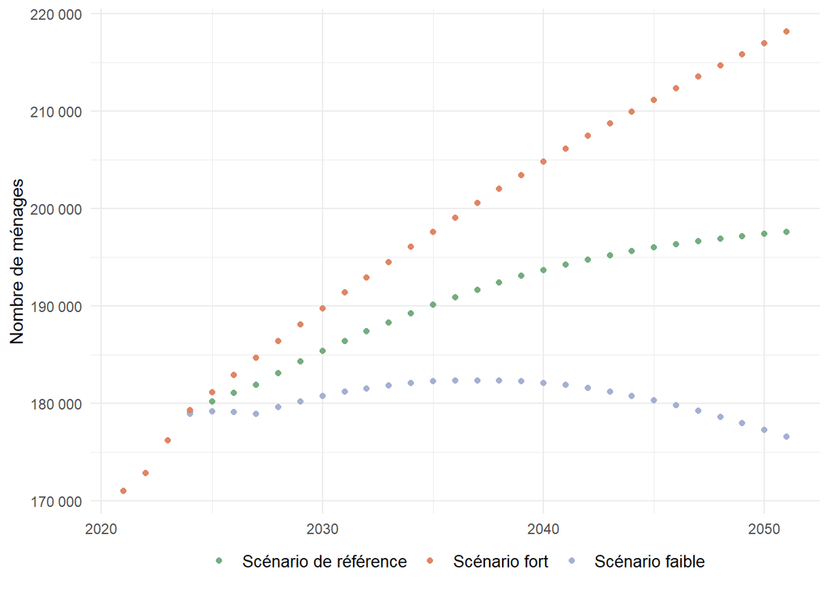

# Occupancy rate

If the ISQ household projections are to be realized, each of these future households will require a dwelling unit to occupy. However, in reality the City will require somewhat more than one dwelling unit per household, since every housing market has some number of unoccupied dwelling units. For rental apartments, these unoccupied units are the basis for the rental vacancy rate, but in the ownership sector as well unoccupied units are a standard feature of a healthy housing market.

The ratio of occupied private dwelling units to all private dwelling units in a given year $t$ is the occupancy rate $TO_t$, and it can be measured empirically using the Canadian Census. The census provides a count of all private dwelling units, derived from the Statistical Building Register which Statistics Canada uses to produce the sampling frame for the census. It also provides a count of households, which is identical to the number of occupied private dwelling units (since households are defined as private dwellings occupied by usual residents). The ratio of the latter measure to the former is the occupancy rate.

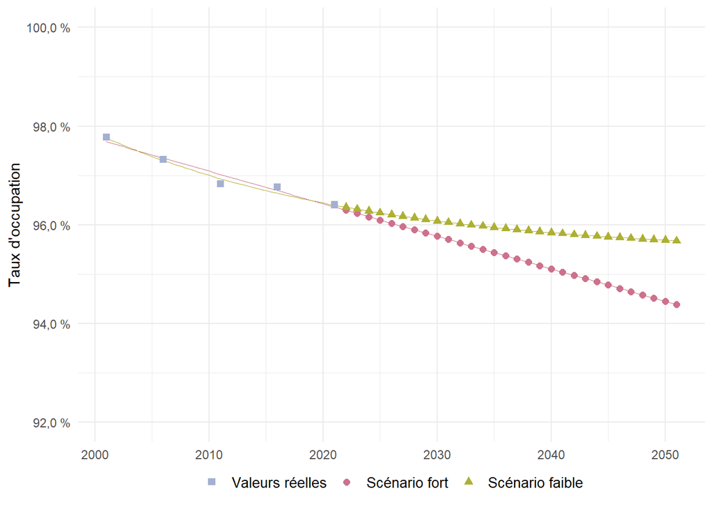

# Total required dwelling units

For each of the ISQ’s scenarios of household growth, the ratio of the number of projected households to the projected occupancy rate in a year ($\frac{MÉ_t}{TO_t}$) yields a required number of total dwelling units for that year. For each of the three ISQ scenarios (reference, weak and strong) there are two total dwelling unit scenarios, corresponding to the two occupancy rate scenarios (weak and strong). Figure TKTK shows these values; since the ISQ’s weak scenario implies a shrinking number of households after 2037, total required dwellings in this scenario also begin to shrink, even taking into account a potentially declining occupancy rate.

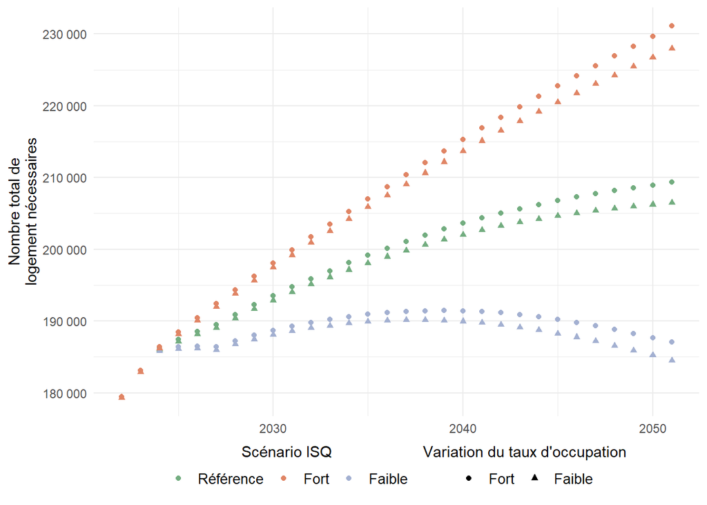

# Dwelling attrition rate

To translate the total required dwelling units each year $t$ into targets for housing production for year $t$, we need to estimate $L_{t-1}$ (the number of existing dwelling units present at the end of year $t-1$), and $TA_t$ (the attrition rate of existing dwelling units due to demolitions and conversions). $L_{t-1}$ is trivial, since it is simply the total required dwelling units for $t-1$ given above in Figure TKTK. $TA_t$ is more difficult to estimate, however, since there is no stable longitudinal data source enumerating the loss of housing units.

We estimate $TA$ by combining two datasets: the total number of private dwelling units from the census and the number of annual housing completions from the CMHC Starts and Completions Survey. The census provides a reliable estimate of the number of private dwelling units in each census period, and if there were no attrition of private dwelling units, then $L_t$ would equal $L_{t-5} + \sum_{i = t - 4}^{t}{MC_i}$, i.e. the previous count of dwelling units plus all the newly completed units. It should therefore be possible to estimate the attrition rate as the difference between this amount and the actual number of dwelling units counted in the census in time $t$, expressed as a proportion of actual units:

$$\frac{L_{t-5} + \sum_{i = t - 4}^{t}{MC_i}-L_t}{L_t}$$
This formula estimates the percentage of dwelling units which were removed from the market over a five-year inter-census period. In theory it would be desirable to examine this relationship longitudinally, to see if the attrition rate has been constant or has varied, but in practice there is too much uncertainty involved in combining the different data sources for this to be reliable. Instead, we opted to calculate the average estimated attrition rate over the 2001-2021 period, which is 0,2 % per year, and assume that this rate will hold steady for the study period.

In theory it would be possible to model attrition using the age of buildings, since the attrition rate should be higher for older buildings, but in practice we also did not find this to be a reliable method, for two reasons. The first is that the construction date categories from the census are not sufficiently fine-grained to allow us to construct consistent measures of building age. The second is that building construction date is provided in the 25% sampled long-form census as a subset of *occupied* private dwellings only, so it is impossible to reliably extrapolate building ages of all dwelling units.

A final, possibly better alternative would be to measure attrition using the City of Laval’s assessment roles. If the UEF could be provided in a longitudinal form with a sufficiently long history, and subject to the assumptions that building ages are accurately recorded and demolitions or conversions are reported in a timely fashion, a more sophsiticated building attrition model could be devleoped. We did not have access to such data, however, so we opted for a simple constant attrition rate relying on the census.

# Annual housing completion targets

Using the procedure outlined above, the components to the global model $MC_t = \frac{MÉ_t}{TO_t} - L_{t-1}*(1-TA)$ can be estimated, and the number of annually required housing completions can be calculated. These are shown in Figure TKTK for the six scenarios we investigated. We set a floor of zero housing completions per year, so that the cases where the ISQ’s household projections forecast shrinking household counts do not yield negative annual housing completions.

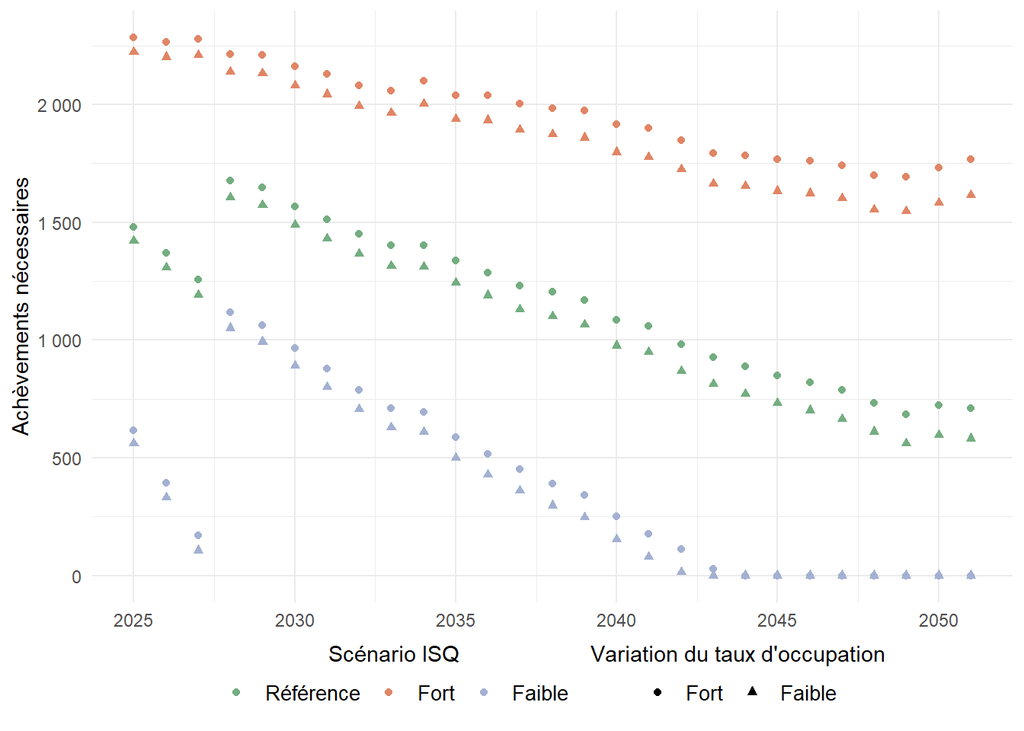

# The lag between housing starts and completions

The targets provided in the previous section are for annual housing completions: finished housing units entering the market. The City does not directly influence completions, however; its role in zoning and permitting construction instead allows it to influence housing starts. How can the completions targets provided above be translated into starts targets instead?

It is not possible to achieve this translation with precision without examining the typology mix of new housing construction, since different housing types have very different construction lengths. However, previous research using detailed building-level records has established two years as the length of time in which most housing starts result in a completion (Somerville 2001). We investigated this question with aggregated data in the Laval context by comparing annual housing completions with housing starts lagged by different numbers of years, in both cases with data drawn from the CMHC Starts and Completions Survey. As Figure TKTK suggests, there is a strong relationship between the housing completions in one year and the housing starts both one and two years prior. But the relationship breaks down with larger or smaller lags. Combining these results with the previous research which found that most construction is completed within two years suggests that the City could reasonably adopt a two-year lag between starts and completions as a rule of thumb. We further conducted a linear regression of two-year lagged housing starts and completions, and this displays randomly distributed residuals, which suggests that there is no bias in the relationship between the two variables.

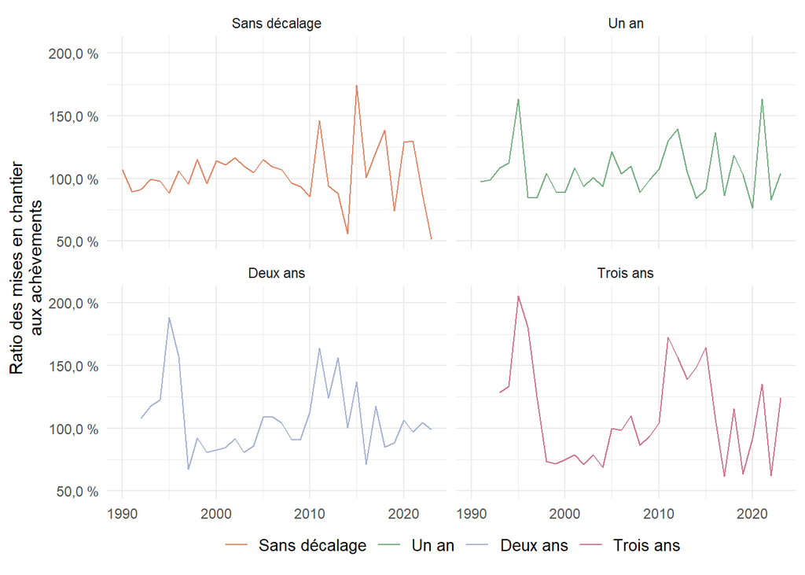

# Scenarios for typology-specific housing targets

As discussed above, typology mix is the main policy lever which allows the City to influence housing affordability in Laval. The City may therefore wish to be deliberate about which housing types it encourages and which types it discourages in the future. Accordingly, we define three plausible scenarios to guide housing targets by housing type. Each of these scenarios involves decomposing either the total dwelling targets or the completion targets established above into three housing types: single-detached homes, apartments, and other (semi-detached, row houses, etc.). These scenarios do not distinguish between large and small apartments, nor between rental and condominium apartments.

Scenario 1 defines the amount of housing construction necessary to preserve the typology mix found in the City of Laval in the 2021 census. In other words, under this scenario, with whatever trajectory for total dwelling units the City tries to achieve, it does so in a way which would be expected to retain roughly 44,8 % of dwelling units as single-detached homes, 40,2 % as apartment units, and 15,0 % as semi-detached homes, row houses, and plexes. Given that the share of dwelling units located in apartment buildings has been increasing over the last twenty years, this scenario would imply a halt to that trend.

Secnario 2 draws on the fact that the number of non-apartment housing units built in Laval has been quite stable in the last decade, and extends that trend into the future. This scenario thus holds non-apartment starts constant at their 2014-2023 average rate (175.5 for single-detached homes and 46.55 for other non-apartment homes), and assumes that the remainder of housing starts will be apartment buildings. If a large total number of new units are projected, this will imply a large number of apartment units, while if a small total number of new units are projected, this will imply a small number of apartment units. But in both cases, the number of non-apartment units constructed will be steady.

# Completion targets for typology scenario 1

Projecting the necessary total dwelling units by type under scenario 1 is straightforward, since it simply involves applying the 2021 ratio between dwelling types to the total dwelling units implied by the six total dwelling unit scenarios developed above. Figure TKTK gives these annual values.

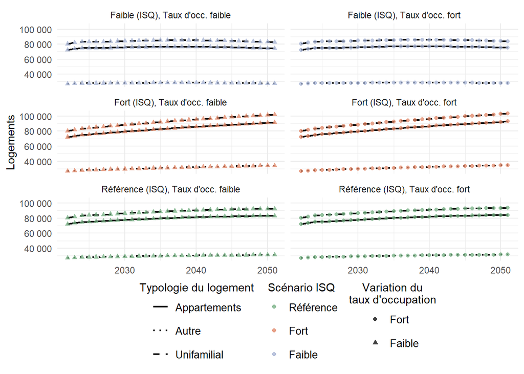

We factor in expected dwelling attrition in the same manner as with the general housing targets described above. Importantly, this implies assuming that the attrition rate is constant across dwelling type. This is almost certainly not true, but we do not have the data that would allow us to make an empirically informed estimate of per-dwelling-type building attrition rates. The result is the annual completion targets shown in Figure TKTK. As with the overall completions targets developed above, we fix annual completions to a minimum of zero units.

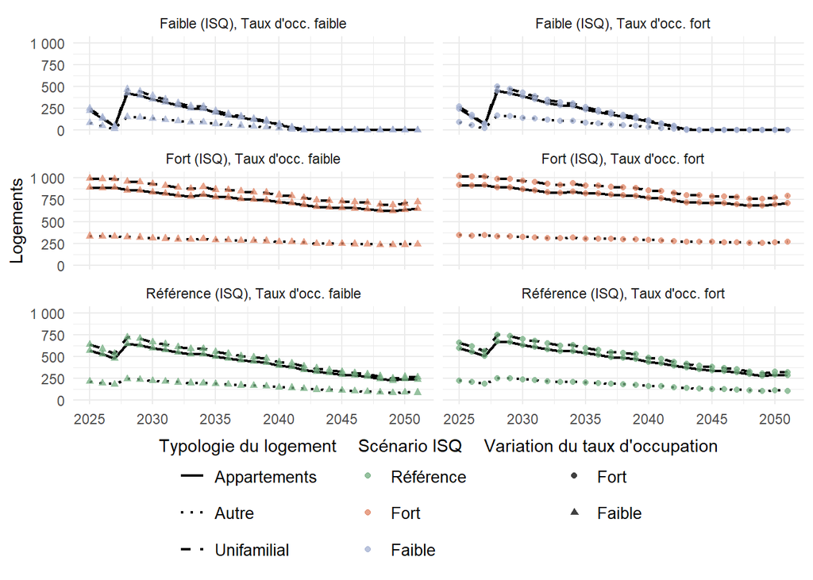

# Completion targets for typology scenario 2

Since scenario 2 assumes a certain number of housing starts and completions rather than total dwelling units, we do not produce total dwelling targets. Instead, we take the global housing completion targets developed above, apply the fixed number of non-apartment housing completions assumed by the scenario (175.5 for single-detached homes and 46.55 for other non-apartment homes), and assume that remaining completions will be apartment units. This gives the annual completion targets shown in Figure TKTK. As with previous completion targets, we fix annual completions to a minimum of zero, and where the total number of completions is less than the fixed sum of non-apartment completions we proportionately allocate the completions between single-detached and other units.

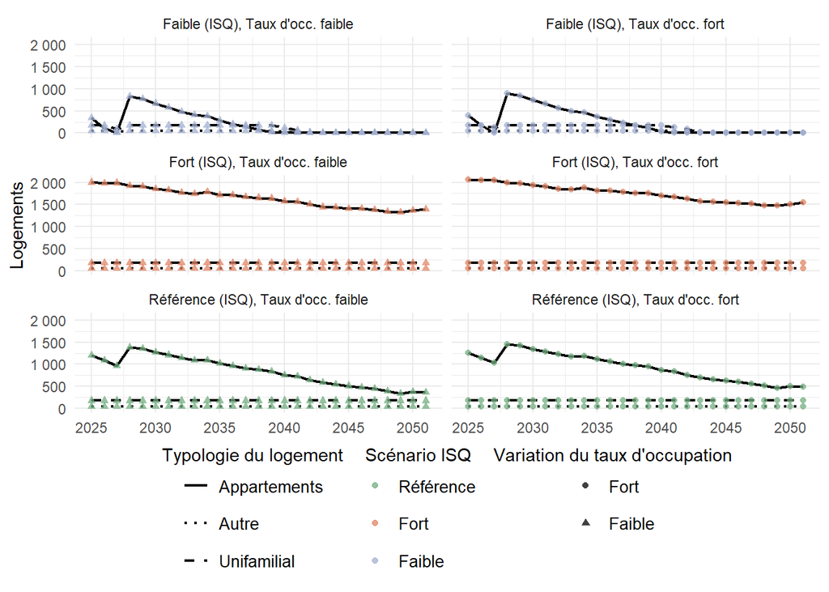

# Completion targets for typology scenario 3

Scenario 3 is also based off of starts and completions rather than total dwelling units. In this case, we divide the global housing completion targets proportionately betweeen the three housing types, with minimum completions fixed to zero. The results are shown in Figure TKTK.

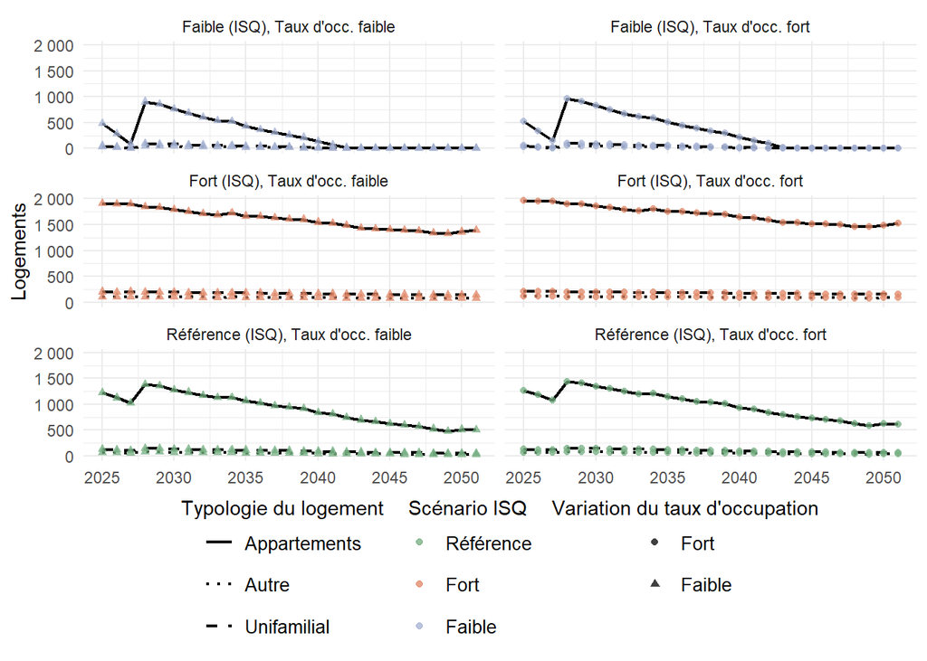

# Starts versus completions by typology

Modeling housing development by dwelling type allows us to incorporate a more sophisticated perspective on the temporal relationship between housing starts and completions. We use historical trends in construction lengths to build year- and type-specific probability distribution functions for construction time as follows:

$$SR_{t, type} \sim N(\mu_{t, type}, \sigma_{type})$$
In other words, each dwelling type has construction times which are normally distributed around a time- and type-specific mean, with a type-specific standard deviation. In combination with information about the seasonality of housing starts, this approach allows us to estimate the distribution of lags between starts and completions.

Figure TKTK shows the average construction length of new housing construction by dwelling type. Two trends are evident. First, the construction time for apartments has been steadily increasing, from roughly half a year in the early 2000s to close to roughly 15 months in the 2020s. Second, non-apartment construction lengths have been quite stable, with particularly little variation in average construction length in the last decade.

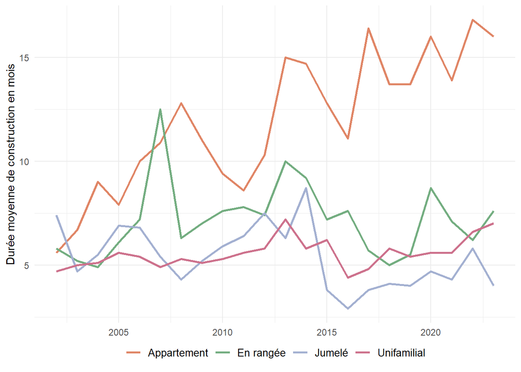

We therefore assume that non-apartment construction lengths will remain constant in the future: 5.72 months for single-detached homes and 5.795 for semi-detached and row houses. And we apply linear regression to the 2014-2023 trend in apartment construction lengths to project future construction lengths for this dwelling type.

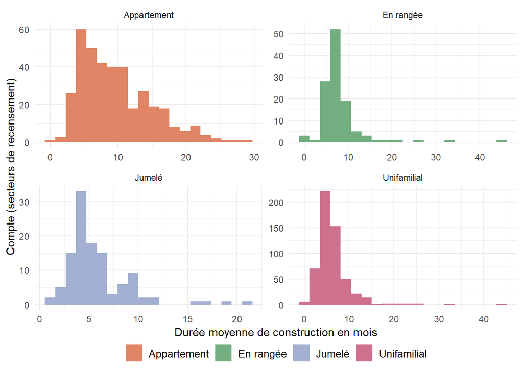

Finally, we retrieve type-specific housing completion frequencies by month to establish the seasonality of housing construction. Figure TKTK displays these frequencies, and demonstrates consistent winter lows and summer highs in housing completions, and relatively little variation between dwelling types.

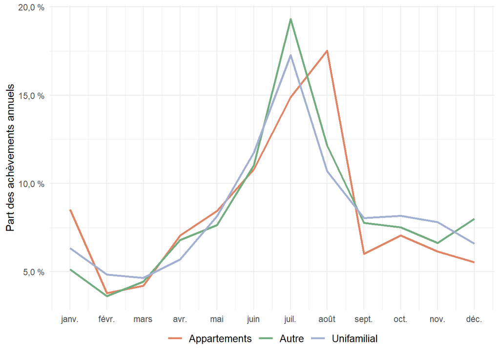

# Start targets for typology scenario 1

The estimated number of housing starts necessary by dwelling type to achieve the annual completions called for under typology scenario 1 are given in Figure TKTK.

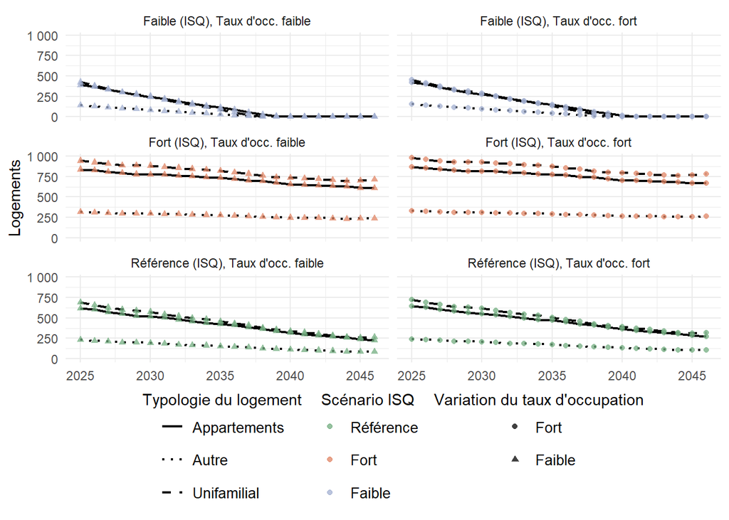

# Start targets for typology scenario 2

The estimated number of housing starts necessary by dwelling type to achieve the annual completions called for under typology scenario 2 are given in Figure TKTK.

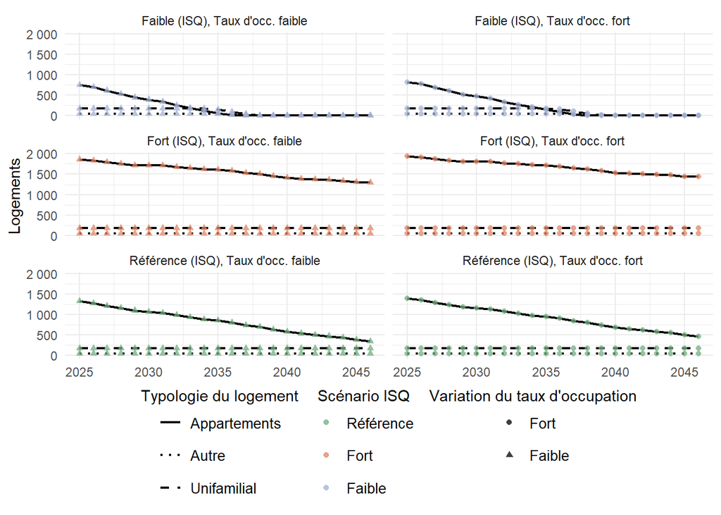